## Individual Assignment #2: ARIMA Lab.

#### Due: Nov. 23 before class time

#### (40 points)

The file titled **US Electricity.csv** includes a time series index compiled by the US Federal Reserve representing total fossil-fuel US electricity generation by all utilities from January 1939 through October 2021.

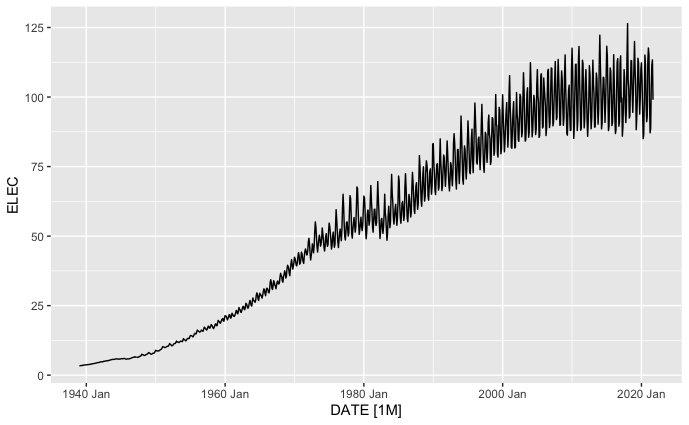

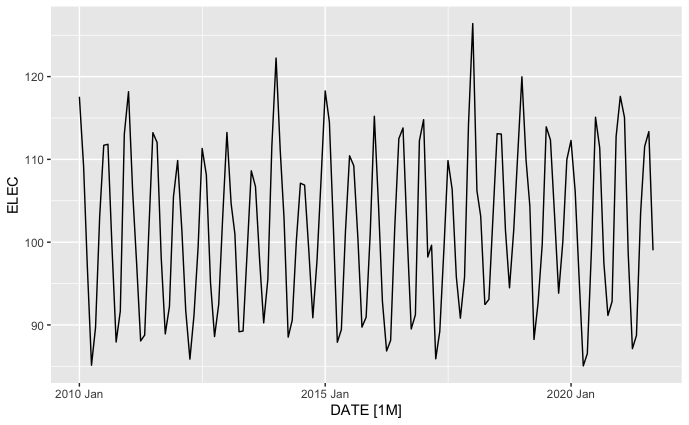

We are interested in developing a two-year long monthly forecast (24 months) for the national electricity production requirements.

1. Examine the stationarity of the **ELEC** time series in the reduced **DR** data, examine also the corresponding ACF and PACF diagrams and propose three plausible ARIMA models to fit the data.

The first step in fitting an ARIMA model to model a time-series is to determine if the time series is stationary and if it is not, determine how many differences is neccessary to make it stable.

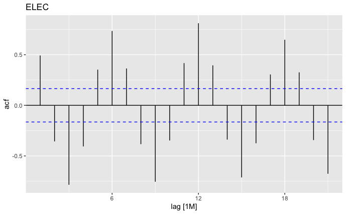

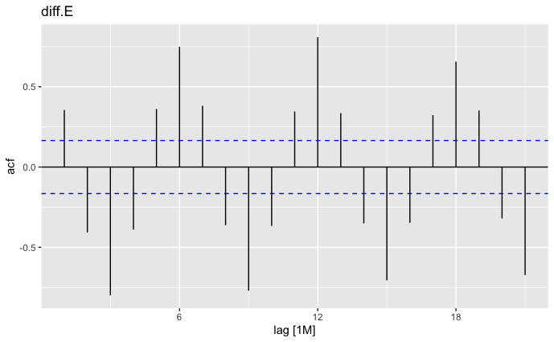

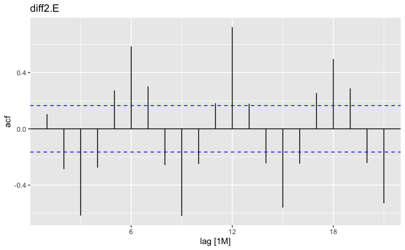

```r
DR %>%
  mutate(diff.E = difference(ELEC),
         diff2.E = difference(diff.E)) -> DE

DE %>% ACF(ELEC) %>%
  autoplot() +
  labs(title = "ELEC")
DE %>% ACF(diff.E) %>%
  autoplot() +
  labs(title = "diff.E")

DE %>% ACF(diff2.E) %>%
  autoplot() +
  labs(title = "diff2.E")
```

Next we examine ADF and the unit roots test results on these three time series.

The Null Hypothesis of the KPSS root test is that data is stationary, hence we need to obtain a large value of p so we CANNOT reject the Null Hypothesis

On the other hand the Null Hypothesis of the ADF test is that the data is NOT stationary, hence we need to obtain a small p-value to reject the Null Hypotehsis.

[output not shown]

```r
DE %>% features(ELEC, unitroot_kpss)

DE %>% features(diff.E, unitroot_kpss)
```

| kpss_stat | kpss_pvalue |
| --- | --- |
| 0.04720146 | 0.1 |

```r
DE %>% features(diff2.E, unitroot_kpss)
```

| kpss_stat | kpss_pvalue |
| --- | --- |
| 0.06071587 | 0.1 |

```r
DE %>% features(ELEC, unitroot_ndiffs)
```

| ndiffs |
| --- |
| 0 |

```r
# ADF Test
DE$ELEC%>% adf.test()

DE$diff.E %>%
  na.omit() %>%
  adf.test()

DE$diff2.E %>%
  na.omit() %>%
  adf.test()
```

[output not shown]